# Sales Year Over Year By Department and Category

Sam Pritchard

December 28, 2017

## Headline:

### This document contains exploratory charts for sales year over year by department and category. Some of the categories include comments. This may be data that your systems already generate but I generated these as a part of the process of familiarizing myself with the data and the sales patterns.

## Sales By Departments ’17 vs. ’16

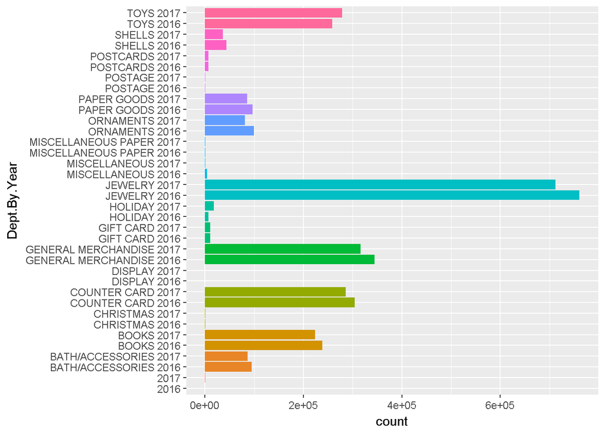

## Sales By Departments ’17 vs. ’16 (Removed Very Small Depts)

Removed the following categories: “POSTAGE”, “MISCELLANEOUS PAPER”, “MISCELLANEOUS”, “GIFT CARD”, “DISPLAY”

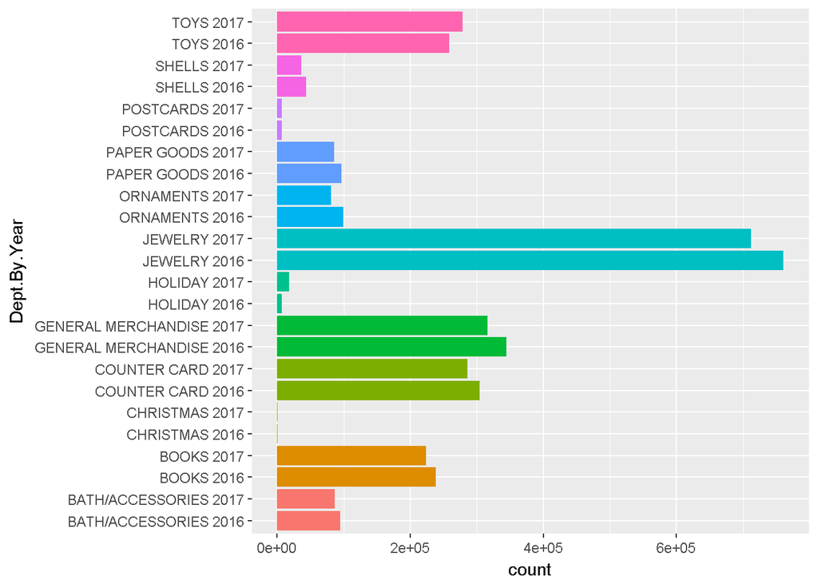

### Jewelry by Category

Slight declines in most major categories but the one in bracelets is larger. The declines follow the trend for the category

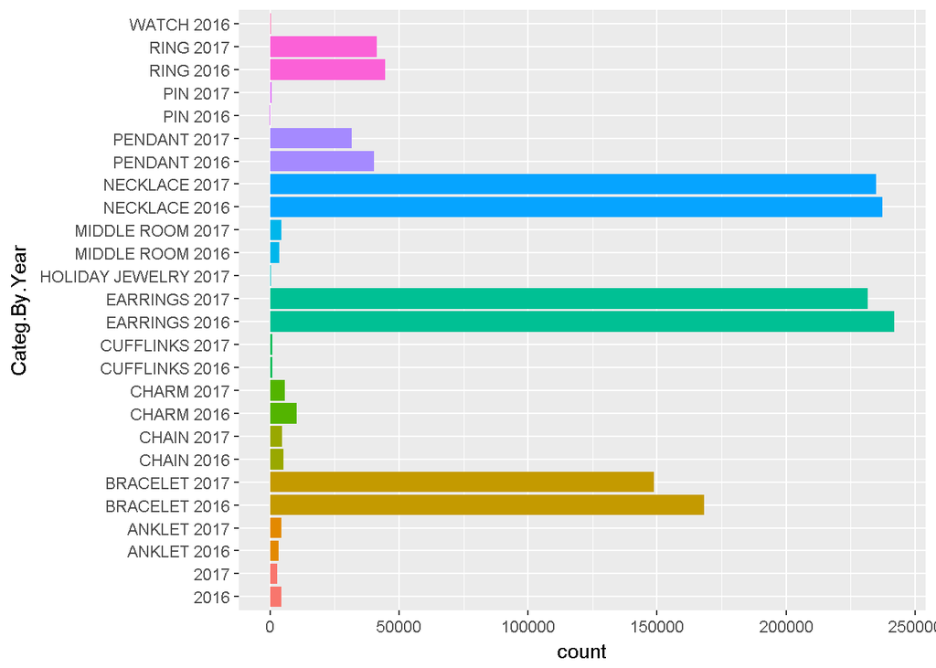

### General Merchandise by Category

The Categories HOUSEWARES, CRAFTS, and ART GLASS were the highest for General Merchandise. Housewares also grew substantially over last year, as did PERS ACCES/BAGS/POUCHES.

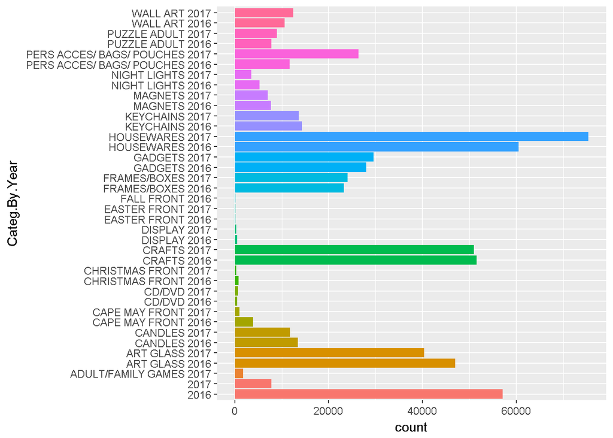

### Counter Card by Category

BIRTHDAY is the largest category by far but saw a slight decline.

The second highest is BLANK cards which also saw an increase in 2017

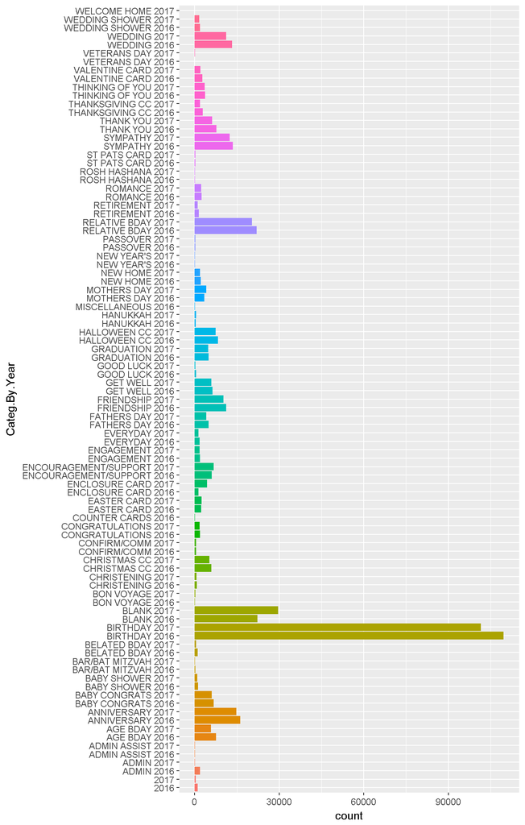

### Toys by Category

IMAGINATIVE PLAY was the top toy category last year and it has continued to an even bigger year as top seller again in 2017.

PLUSH similarly was a really big seller last year (#2) and saw growth on top of that.

Other Categories with big growth were CREATIVE LEARNING, BABY, OUTDOOR FUN.

Notable declines occurred in PUZZLES, PUPPETS, and FINGER PUPPETS

Note that there were more uncategorized TOYS purchases in 2016, so that likely inflates some of the 2017 categories

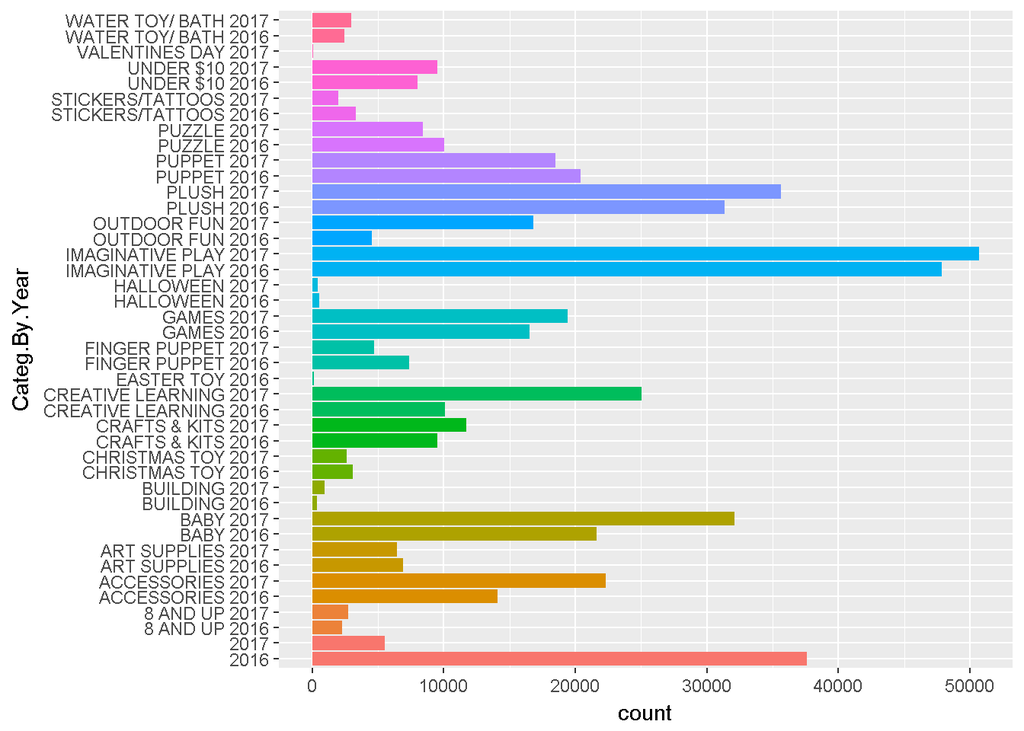

### Books by Category

TOY BOOK HARDBACK is the highest in the category and brings in roughly $80K per year

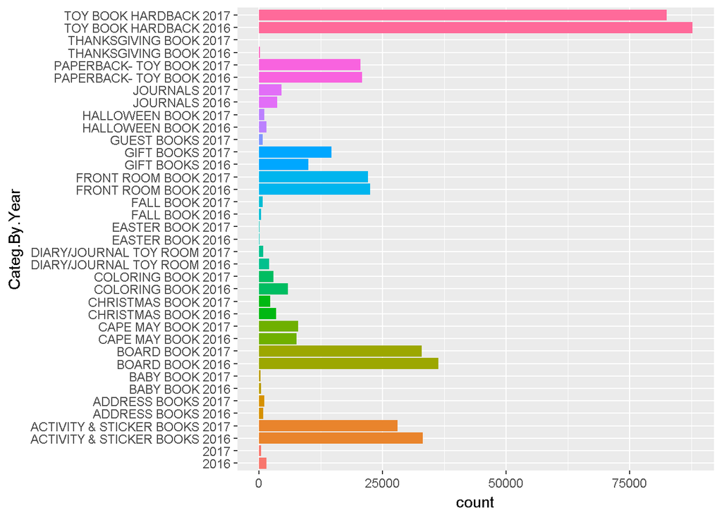